# Logit

Jeffrey B. Arnold

05/29/2015

```r
library("MASS")
library("tidyr")
library("dplyr")
library("broom")
library("ggplot2")
```

## Data

The example data used in this tutorial is individual level turnout data for the 1992 U.S. Presidential election from the American National Election Survey (ANES). The data used here are 2,000 observations from the ANES that are included in the package **Zelig**

```r
library("Zelig")
data("turnout")
```

This data and model is similar to that used in

> King, Gary, Michael Tomz, Jason Wittenberg (2000). “Making the Most of Statistical Analyses: Improving Interpretation and Presentation,” American Journal of Political Science, vol. 44, pp.341–355.

## glm function

To run a logit regression, use the R function `glm`, which stands for generalized linear model.

```r
mod1 <- glm(vote ~ age + I(age ^ 2) + race + educate, data = turnout,
            family = binomial(link = "logit"))
mod1
```

```
##
## Call:  glm(formula = vote ~ age + I(age^2) + race + educate, family = binomial(link = "logit"),
##     data = turnout)
##
## Coefficients:
## (Intercept)          age     I(age^2)    racewhite      educate
##  -4.8329287    0.1192993   -0.0009512    0.3815208    0.2136191
##
## Degrees of Freedom: 1999 Total (i.e. Null);  1995 Residual
## Null Deviance:       2267
## Residual Deviance: 2042  AIC: 2052
```

The call to `glm` looks similar to `lm`. There is a formula that uses the same syntax as `lm`, as well as a `data` argument. Different families correspond to different types of GLMs. The `binomial()` family is for binary outcome variables. The `link="logit"` argument spefies that the type of binary outcome model is a logit model. The argument is named `link` because is specifies a link function, which for binary dependent variables, is the function that maps values of `X \beta` into probabilities. Another option for a link function is `link="probit"` for a probit model, as well as other, lesser used, link functions.

As in `lm`, the summary of the object has more detailed information, including standard errors and p-values of the estimates.

```r
summary(mod1)
```

```
##
## Call:
## glm(formula = vote ~ age + I(age^2) + race + educate, family = binomial(link = "logit"),
##     data = turnout)
##
## Deviance Residuals:
##     Min       1Q   Median       3Q      Max
## -2.5434  -0.8280   0.5627   0.7756   1.8534
##
## Coefficients:
##               Estimate Std. Error z value Pr(>|z|)
## (Intercept) -4.8329287  0.4654526 -10.383  < 2e-16 ***
## age          0.1192993  0.0171073   6.974 3.09e-12 ***
## I(age^2)    -0.0009512  0.0001718  -5.538 3.07e-08 ***
## racewhite    0.3815208  0.1449355   2.632  0.00848 **
## educate      0.2136191  0.0192975  11.070  < 2e-16 ***
## ---
## Signif. codes:  0 '***' 0.001 '**' 0.01 '*' 0.05 '.' 0.1 ' ' 1
##
## (Dispersion parameter for binomial family taken to be 1)
##
##     Null deviance: 2266.7  on 1999  degrees of freedom
## Residual deviance: 2042.2  on 1995  degrees of freedom
## AIC: 2052.2
##
## Number of Fisher Scoring iterations: 4
```

The coefficients of logit are not as transparent to interpret as OLS coefficients since $X \beta$ is on the log-odds ratio .

The type `"link"` (which is the default) is the predicted value of $x_i \beta$, which in units of the link function, $\log(p_i / (1 - p_i))$:

```r
head(predict(mod1, type = "link"))
```

```
##         1         2         3         4         5         6
## 2.2728729 1.2949585 0.4273097 0.4173758 0.4999998 1.8351068
```

The type `"response"` is in units of the dependent value ($\Pr(Y_i = 1)$):

```r
head(predict(mod1, type = "response"))
```

```
##         1         2         3         4         5         6
## 0.9066053 0.7849853 0.6052311 0.6028551 0.6224593 0.8623690
```

The function `predict` has an option `se.fit = TRUE` that can be used to calculate confidence intervals, but it is preferrable to use the simulation methods below.

## broom

As with `lm`, the **broom** package functions `glance`, `tidy`, and `augment` can be used with the results of `glm` objects.

```r
glance(mod1)
```

```
##   null.deviance df.null    logLik      AIC      BIC deviance df.residual
## 1      2266.748    1999 -1021.096 2052.191 2080.196 2042.191        1995
```

```r
tidy(mod1)
```

```
##          term      estimate    std.error  statistic      p.value
## 1 (Intercept) -4.8329286792 0.4654526344 -10.383288 2.954223e-25
## 2         age  0.1192993121 0.0171072671   6.973604 3.089221e-12
## 3    I(age^2) -0.0009512071 0.0001717726  -5.537596 3.066510e-08
## 4   racewhite  0.3815208352 0.1449355162   2.632349 8.479675e-03
## 5     educate  0.2136191076 0.0192975284  11.069765 1.758608e-28
```

```r
glimpse(augment(mod1))
```

```
## Observations: 2000
## Variables:
## $ vote       (int) 1, 0, 0, 1, 1, 1, 0, 1, 1, 1, 1, 1, 0, 0, 1, 1, 1, ...
## $ age        (int) 60, 51, 24, 38, 25, 67, 40, 56, 32, 75, 46, 52, 22,...
## $ I.age.2.   (AsIs) 3600, 2601,  576, 1444,  625, 4489, 1600, 3136, 10...
## $ race       (fctr) white, white, white, white, white, white, white, w...
## $ educate    (dbl) 14, 10, 12, 8, 12, 12, 12, 10, 12, 16, 15, 12, 12, ...
## $ .fitted    (dbl) 2.2728729, 1.2949585, 0.4273097, 0.4173758, 0.49999...
## $ .se.fit    (dbl) 0.11386737, 0.09145796, 0.09653703, 0.10746968, 0.0...
## $ .resid     (dbl) 0.4428274, -1.7533105, -1.3634182, 1.0060600, 0.973...
## $ .hat       (dbl) 0.0010978958, 0.0014118108, 0.0022266492, 0.0027652...
## $ .sigma     (dbl) 1.011963, 1.011249, 1.011550, 1.011760, 1.011776, 1...
## $ .cooksd    (dbl) 2.266988e-05, 1.033777e-03, 6.857980e-04, 3.663559e...
## $ .std.resid (dbl) 0.4430707, -1.7545495, -1.3649387, 1.0074539, 0.974...
```

## First differences

```r
pred_logit <- function(mod, data, sims = 1000, conf.level = 0.95) {
  formula <- delete.response(terms(mod))
  simbetas <- mvrnorm(sims, coef(mod1), vcov(mod1))
  # Turns data in model frame
  X <- model.matrix(formula, data = data)
  phat <- plogis(X %*% t(simbetas))
  lwr <- (1 - conf.level) / 2
  upr <- 1 - lwr
  data.frame(mean = apply(phat, 1, mean),
             lower = apply(phat, 1, quantile, prob = lwr),
             upper = apply(phat, 1, quantile, prob = upr),
             row.names = NULL)
}
```

Predict for different values of age, holding educate at its mean, for both white and others

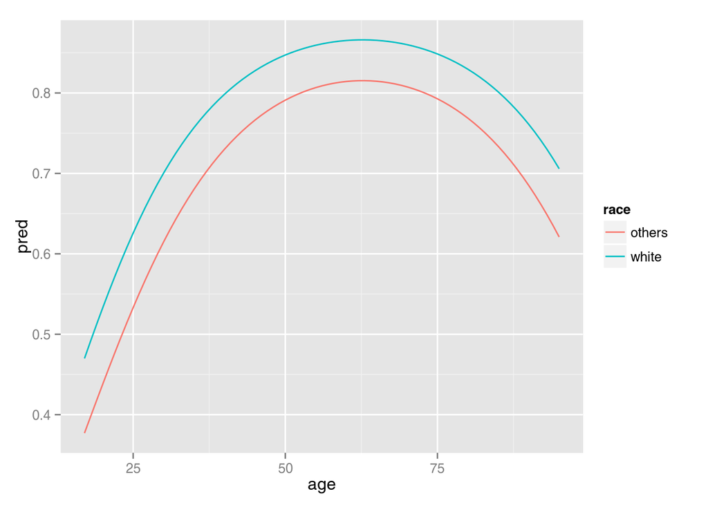

```r
mod1_vary_age <-
  expand.grid(age = min(turnout$age, na.rm = TRUE):max(turnout$age, na.rm = TRUE),
                        race = unique(turnout$race, na.rm = TRUE),
                        educate = mean(turnout$educate, na.rm = TRUE))

mod1_vary_educate <-
  expand.grid(age = mean(turnout$age),
                        race = unique(turnout$race, na.rm = TRUE),
                        educate = unique(turnout$educate))

mod1_pred_age <-
  predict(mod1, newdata = mod1_vary_age,
          type="response")

ggplot(mutate(mod1_vary_age, pred = mod1_pred_age),
       aes(x = age, y = pred, colour = race)) +
  geom_line()
```

Varying education for groups of race, holding age at its mean.

```r
bind_cols(mod1_vary_educate, pred_logit(mod1, mod1_vary_educate))
```

```
##       age   race educate      mean     lower     upper
## 1  45.296  white    14.0 0.8794871 0.8575052 0.8983914
## 2  45.296 others    14.0 0.8322839 0.7840408 0.8723193
## 3  45.296  white    10.0 0.7565780 0.7234822 0.7877599
## 4  45.296 others    10.0 0.6796075 0.6155077 0.7383685
## 5  45.296  white    12.0 0.8265310 0.8018249 0.8490708
## 6  45.296 others    12.0 0.7644646 0.7074824 0.8138446
## 7  45.296  white     8.0 0.6696390 0.6224176 0.7139777
## 8  45.296 others     8.0 0.5809003 0.5080144 0.6487229
## 9  45.296  white    16.0 0.9177864 0.8988825 0.9336282
## 10 45.296 others    16.0 0.8834302 0.8414943 0.9163693
## 11 45.296  white    15.0 0.9002755 0.8802641 0.9174882
## 12 45.296 others    15.0 0.8598175 0.8153193 0.8959310
## 13 45.296  white     9.0 0.7150946 0.6760913 0.7525724
## 14 45.296 others     9.0 0.6316249 0.5628594 0.6937800
```

[output cut: 26 more lines]

Varying age for groups of race, holding education at its mean.

```r
bind_cols(mod1_vary_age, pred_logit(mod1, mod1_vary_age))
```

```
##     age   race  educate      mean     lower     upper
## 1    17  white 12.06675 0.4698600 0.3906913 0.5436461
## 2    18  white 12.06675 0.4911898 0.4171146 0.5599219
## 3    19  white 12.06675 0.5121099 0.4432238 0.5762019
## 4    20  white 12.06675 0.5325421 0.4656931 0.5917934
## 5    21  white 12.06675 0.5524184 0.4919512 0.6070460
## 6    22  white 12.06675 0.5716809 0.5156586 0.6224072
## 7    23  white 12.06675 0.5902826 0.5379827 0.6372180
## 8    24  white 12.06675 0.6081867 0.5592344 0.6518597
## 9    25  white 12.06675 0.6253662 0.5797454 0.6658579
## 10   26  white 12.06675 0.6418031 0.5994976 0.6788481
## 11   27  white 12.06675 0.6574878 0.6191384 0.6921062
## 12   28  white 12.06675 0.6724181 0.6360033 0.7049480
## 13   29  white 12.06675 0.6865982 0.6517729 0.7171785
## 14   30  white 12.06675 0.7000377 0.6665668 0.7286317
```

[output cut: 144 more lines]

## Marginal Effects

```r
mfx <-
  augment(mod1, type.predict = "response") %>%
    mutate(dy = .fitted * (1 - .fitted),
             mfx_age = dy *
             (coef(mod1)["age"] + 2 * coef(mod1)["I(age^2)"] * age),
           mfx_educate = dy * coef(mod1)["educate"],
           mfx_racewhite = dy * coef(mod1)["racewhite"])
```

Now we can plot the marginal effects for each

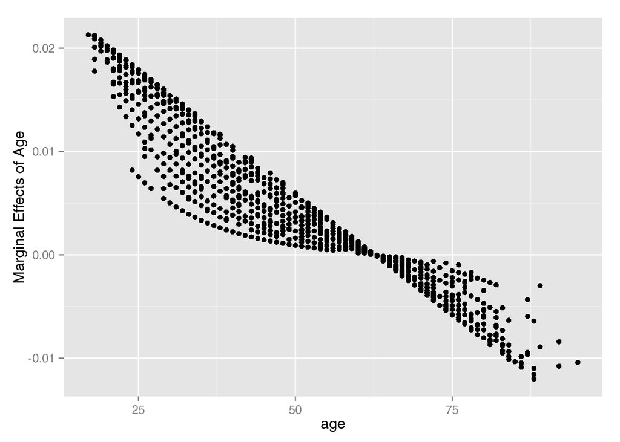

```r
ggplot(mfx, aes(x = age, y = mfx_age)) +
  geom_point() +
  ylab("Marginal Effects of Age")
```

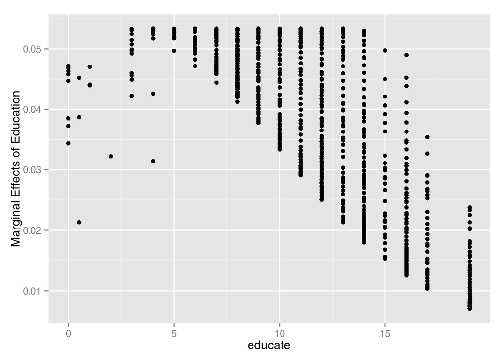

```r
ggplot(mfx, aes(x = educate, y = mfx_educate)) +
  geom_point() +
  ylab("Marginal Effects of Education")
```

Marginal effects do not make much sense for binary covariates, and first differences make more sense. In any case, this only makes sense to calculate for non-white individuals.

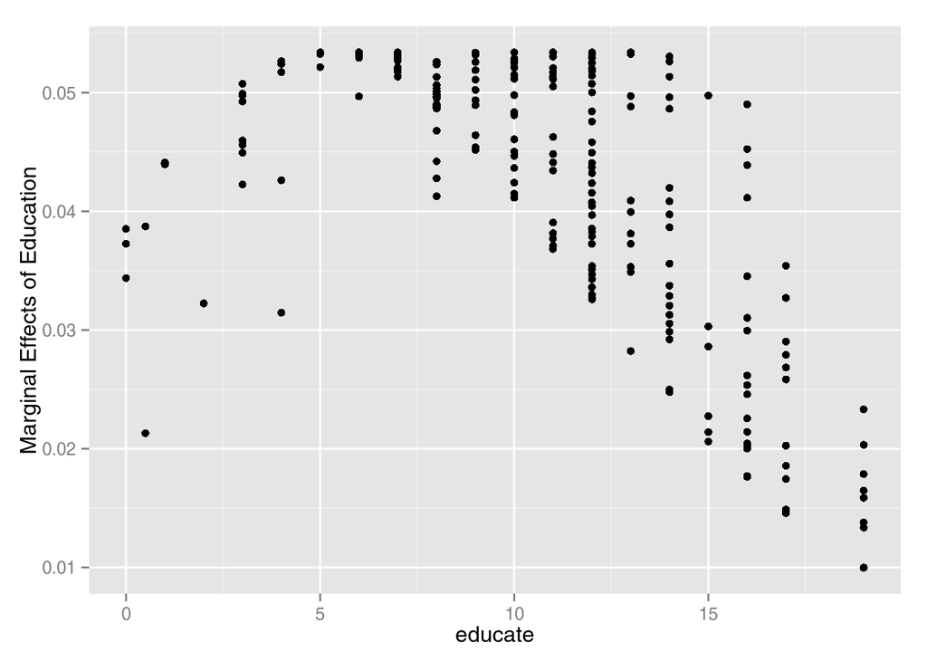

```r
ggplot(filter(mfx, race == "others"),
       aes(x = educate, y = mfx_educate)) +
  geom_point() +
  ylab("Marginal Effects of Education")
```

One way of summarizing the effect of a variable is to average these marginal effects over all the individuals in the sample

```r
summarise_each(mfx, funs(mean), matches("mfx_"))
```

```
##       mfx_age mfx_educate mfx_racewhite
## 1 0.006163171  0.03591468    0.06414314
```

Note: in the code above I used `matches` to select all variables matching a pattern. See the `dplyr` documentation for `select` for more information.

## Assessing model fit

### AIC / BIC

There are multiple methods to assess model fit for logit models. The simplest are the AIC and BIC, which are defined as, $\begin{aligned}[t] AIC &= 2 k - 2 * \log(L) \\ BIC &= k * \log(n) - 2 * \log(L) \end{aligned}$ where $L$ is the log-likelihood of the model at its maximum likelihood estimates, $k$ is the number of variables, and $n$ is the number of observations. The both work in a similar manner, taking how well the model explains the data (the log-likelihood) and penalizing it for complexity (in terms of parameters). For most values of $k$ and $n$, the BIC penalizes the complexity more and chooses simpler models. For both AIC and BIC, the model with the *smaller* value is preferred.

You can calculate the AIC and BIC using functions of the same names,

```r
AIC(mod1)
```

```
## [1] 2052.191
```

```r
BIC(mod1)
```

```
## [1] 2080.196
```

Note that these are not statistics, so there is no test as to whether the AIC of models are the same or a clear meaning for the difference of AIC between models. All you can say is that the model with the lower AIC is preferred.

## Classification Peformance

One way to assess model performance is to pick a threshold with which to assign predicted probabilities to either 0 or 1, and then compare then with the actual values of either 0 or 1.

Here’s a simple function (created by Brian Greenhill) that gives you the same information in a more user-friendly way.

```r
contingencytable <- function(modelobject, threshold = 0.5) {
    phat <- fitted(modelobject)
    y <- model.response(model.frame(modelobject))

    tp <- (phat >= threshold & y == 1)
    fp <- (phat >= threshold & y == 0)
    tn <- (phat < threshold & y == 0)
    fn <- (phat < threshold & y == 1)

    results <- matrix(c(sum(tn), sum(fp), sum(fn), sum(tp)), 2, 2)
    rownames(results) <- c("Predicted Non-Events", "Predicted Events")
    colnames(results) <- c("Actual Non-Events", "Actual Events")

    fpr <- sum(fp)/(sum(tn) + sum(fp))
    tpr <- sum(tp)/(sum(tp) + sum(fn))

    print(results)
    cat(paste("\nFalse positive rate is", round(fpr, 2), "\nTrue Positive Rate is",
        round(tpr, 2)))

    invisible(list(fpr = fpr, tpr = tpr))
}
```

For example, to calculate a contigency table using the natural threshold of 0.5,

```r
contingencytable(mod1, threshold = 0.5)
```

```
##                      Actual Non-Events Actual Events
## Predicted Non-Events                82            55
## Predicted Events                   426          1437
##
## False positive rate is 0.84
## True Positive Rate is 0.96
```

## ROC

```r
library("ROCR")
```

You can imagine running this over a range of different thresholds. The next tool, the ROC plot. Each pair of FPR and TPR values represents one point on the ROC curve.

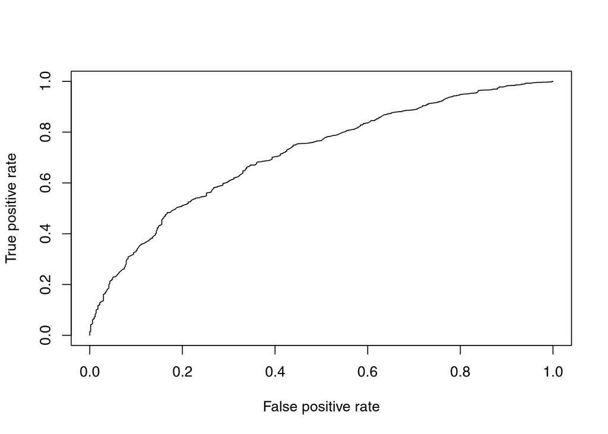

```r
pred_mod1 <- prediction(mod1$fitted.values, mod1$y)
perf_mod1 <- performance(pred_mod1, "tpr", "fpr")
plot(perf_mod1)
```

The ROC curve is interesting, but if we want a single number with which to compare models, we can use the AUC (area unde r the curve) of the ROC plot. Plots with higher AUC values have better classification success averaging overall all possible threshhold values.

```r
performance(pred_mod1, "auc")@y.values[[1]]
```

```
## [1] 0.713991
```

```r
isS4(performance(pred_mod1, "auc"))
```

```
## [1] TRUE
```

See more:

- http://www.r-bloggers.com/a-small-introduction-to-the-rocr-package/
- http://www.r-bloggers.com/an-example-of-roc-curves-plotting-with-rocr/

## separation plots

The separation plot is a graphical method for assessing the model fit of binary response models.

> Greenhill, Brian, Michael D. Ward, and Audrey Sacks. 2011. “The Separation Plot: A New Visual Method for Evaluating the Fit of Binary Models.” American Journal of Political Science 55(4): 991–1002. http://onlinelibrary.wiley.com/doi/10.1111/j.1540-5907.2011.00525.x/abstract

The authors implement this method in the R package **separationplot** (available on CRAN):

```r
library("separationplot")
```

Here is a separation plot applied to `mod1`

```r
separationplot(fitted(mod1), turnout$vote, newplot = TRUE)
```

[output not shown]

## actual-versus-predicted (AVP) plots

The idea behind the AVP plot is that if the model is working well, for observations where it predicts that $\hat p$% of the observations are 1’s, $\hat p$% of the observations should be 1s. In order to calculate this, since the $\hat p$ will take many values, we need to bin the observations by values of $\hat p$. The function `avpbins` does that.

```r
avpbins <- function(x, predicted, breaks = 10, ...) {
  hh <- hist(x, breaks = breaks, ..., plot = FALSE)
  data_frame(bin = findInterval(fitted(mod1), hh$breaks),
             actual = x) %>%
    group_by(bin) %>%
    dplyr::summarize(actual = mean(actual),
              count = length(bin)) %>%
    right_join(data_frame(bin = seq_len(length(hh$mids)),
                          fitted = hh$mids),
               by = "bin") %>%
    mutate(actual = ifelse(! is.na(actual), actual, 0),
           count = ifelse(! is.na(count), count, 0),
           density = count / sum(count))
}
```

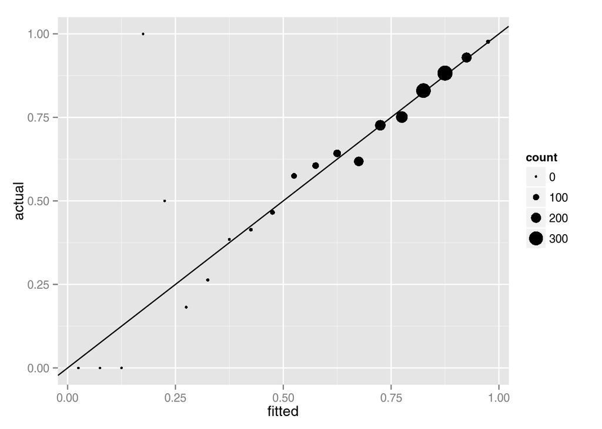

```r
ggplot(avpbins(mod1$y, fitted(mod1), breaks = seq(0, 1, by = 0.05)),
       aes(x = fitted, y = actual, size = count)) +
  geom_point() +
  geom_abline(slope = 1, intercept = 0)
```

Chris Adolph has an alternative implementation of the actual-versus-predicted plot on his [site](http://faculty.washington.edu/cadolph/?page=60).

## Heatmap fit

A method similar to actual-versus-predicted plots was introduced in

> Esarey, Justin, and Andrew Pierce. 2012. “Assessing Fit Quality and Testing for Misspecification in Binary-Dependent Variable Models.” Political Analysis 20(4): 480–500. http://pan.oxfordjournals.org/content/20/4/480

The heatmap fit plot plots a line with the empirical probability of the response against the fitted probability. The ideal line would follow a 45 degree line. The authors implemented this method in the package **heatmapFit** (available on CRAN).

```r
library("heatmapFit")
```

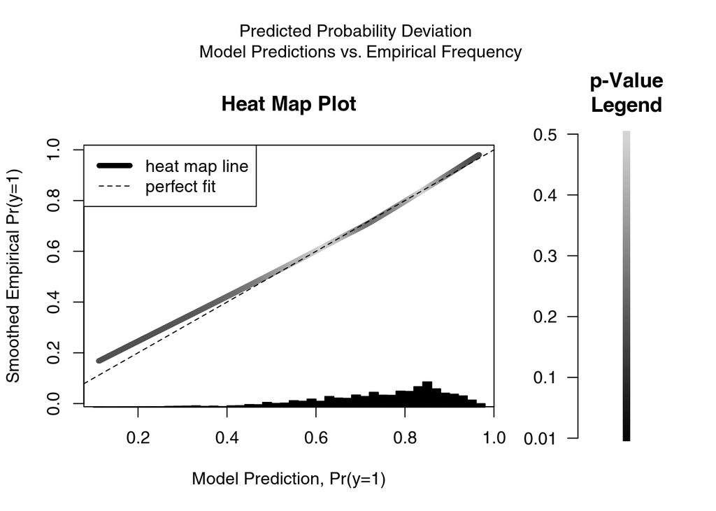

```r
heatmap.fit(turnout$vote, fitted(mod1))
```

```r
dev.off()
```